# HW 6

Tanush

17/11/2024

The dataset includes the following relevant columns for regression analysis:

Dependent variable: Weekly_Sales (target variable).

Independent variables: Holiday_Flag (0 for false, 1 for true) Temperature Fuel price CPI (Consumer Price Index, tracks price change over time) Unemployment

# 1. Perform regression (2 Points)

```r
# Load necessary libraries
library(UsingR)
library(readxl)

# Load the dataset
data <- read_excel("Walmart_Sales.xlsx", sheet = "Walmart_Sales")

# Perform linear regression
model <- lm(Weekly_Sales ~ Holiday_Flag + Temperature + Fuel_Price + CPI + Unemployment, data = data)

# Summary of the model
summary(model)
```

```
##
## Call:
## lm(formula = Weekly_Sales ~ Holiday_Flag + Temperature + Fuel_Price +
##     CPI + Unemployment, data = data)
##
## Residuals:
##      Min       1Q   Median       3Q      Max
## -1022429  -478555  -117266   397246  2800620
##
## Coefficients:
##               Estimate Std. Error t value Pr(>|t|)
## (Intercept)  1726523.4    79763.5  21.646  < 2e-16 ***
## Holiday_Flag   74891.7    27639.3   2.710  0.00675 **
## Temperature     -724.2      400.5  -1.808  0.07060 .
## Fuel_Price    -10167.9    15762.8  -0.645  0.51891
## CPI            -1598.9      195.1  -8.194 3.02e-16 ***
## Unemployment  -41552.3     3972.7 -10.460  < 2e-16 ***
## ---
## Signif. codes:  0 '***' 0.001 '**' 0.01 '*' 0.05 '.' 0.1 ' ' 1
##
## Residual standard error: 557400 on 6429 degrees of freedom
## Multiple R-squared:  0.02544,    Adjusted R-squared:  0.02469
## F-statistic: 33.57 on 5 and 6429 DF,  p-value: < 2.2e-16
```

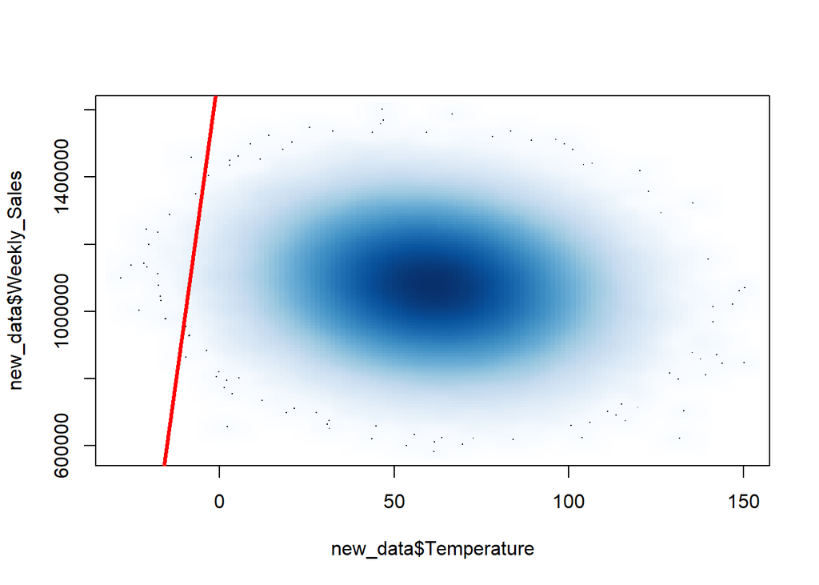

```r
# Create Sample Records for simulation
new_data <- data.frame(Holiday_Flag = sample(0:1, 1e6, replace = TRUE),
                       Temperature = rnorm(1e6, mean = mean(data$Temperature), sd = sd(data$Temperature)),
                       Fuel_Price = rnorm(1e6, mean = mean(data$Fuel_Price), sd = sd(data$Fuel_Price)),
                       CPI = rnorm(1e6, mean = mean(data$CPI), sd = sd(data$CPI)),
                       Unemployment = rnorm(1e6, mean = mean(data$Unemployment), sd = sd(data$Unemployment)))

# Predict Weekly_Sales for the new data
new_data$Weekly_Sales <- predict(model, newdata = new_data)

# Visualize Simulated Data
smoothScatter(new_data$Temperature, new_data$Weekly_Sales)
abline(model, col="red", lwd=3)
```

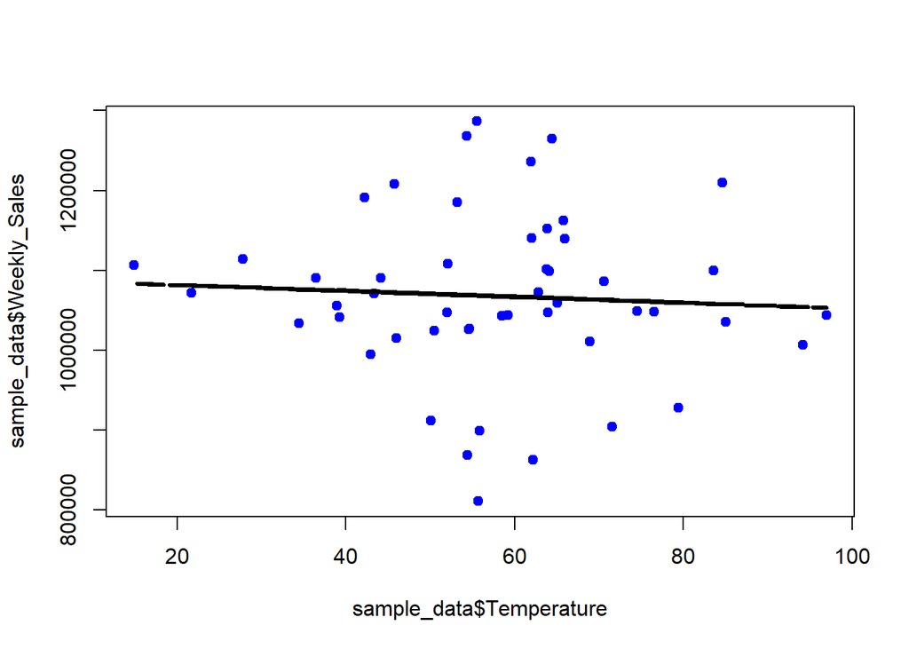

```r
# Sample from the new dataset
set.seed(12345)
sample_data <- new_data[sample(1:1e6, 50, replace = FALSE),]

# Plot Sample Data
plot(sample_data$Temperature, sample_data$Weekly_Sales, pch=19, col="blue")

# Perform Linear Regression on Sample Data
sample_model <- lm(Weekly_Sales ~ Temperature, data = sample_data)
lines(sample_data$Temperature, sample_model$fitted, lwd=3, lty=2)
abline(model, col="red", lwd=3)
```

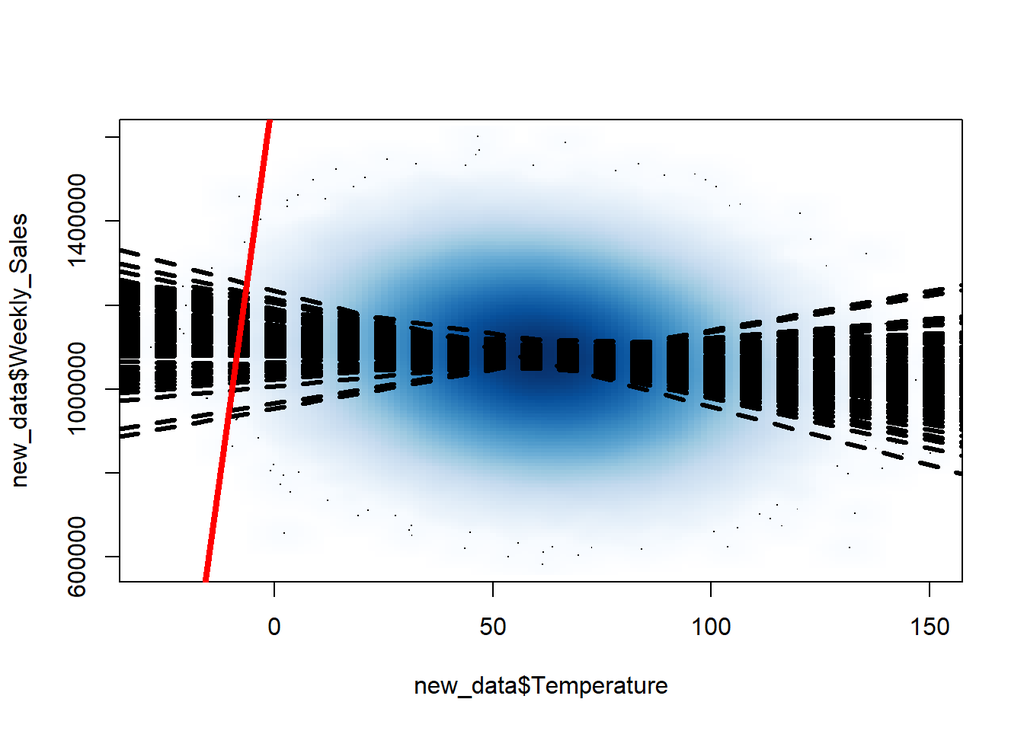

```r
# Perform Multiple Sampling and Plot
sample_models <- vector("list", 100)
for(i in 1:100){
  sample_data <- new_data[sample(1:1e6, 50, replace = FALSE),]
  sample_models[[i]] <- lm(Weekly_Sales ~ Temperature, data = sample_data)
}

# Visualize Multiple Sample Models
smoothScatter(new_data$Temperature, new_data$Weekly_Sales)
for(i in 1:100) { abline(sample_models[[i]], lwd=3, lty=2) }
abline(model, col="red", lwd=4)
```

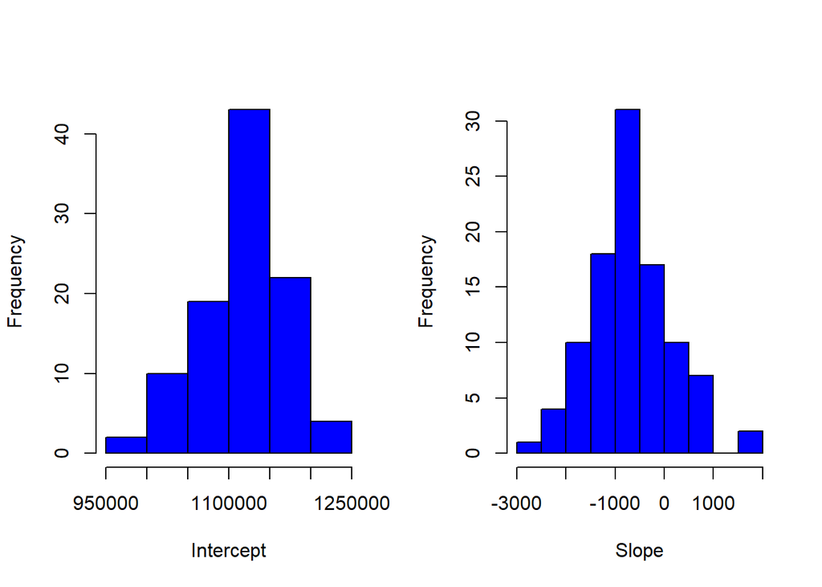

```r
# Histogram of Coefficients
par(mfrow=c(1,2))
hist(sapply(sample_models, function(x) coef(x)[1]), col="blue", xlab="Intercept", main="")
hist(sapply(sample_models, function(x) coef(x)[2]), col="blue", xlab="Slope", main="")
```

```r
# Model Interpretation and Diagnostics
summary(model)
```

```
##
## Call:
## lm(formula = Weekly_Sales ~ Holiday_Flag + Temperature + Fuel_Price +
##     CPI + Unemployment, data = data)
##
## Residuals:
##      Min       1Q   Median       3Q      Max
## -1022429  -478555  -117266   397246  2800620
##
## Coefficients:
##               Estimate Std. Error t value Pr(>|t|)
## (Intercept)  1726523.4    79763.5  21.646  < 2e-16 ***
## Holiday_Flag   74891.7    27639.3   2.710  0.00675 **
## Temperature     -724.2      400.5  -1.808  0.07060 .
## Fuel_Price    -10167.9    15762.8  -0.645  0.51891
## CPI            -1598.9      195.1  -8.194 3.02e-16 ***
## Unemployment  -41552.3     3972.7 -10.460  < 2e-16 ***
## ---
## Signif. codes:  0 '***' 0.001 '**' 0.01 '*' 0.05 '.' 0.1 ' ' 1
##
## Residual standard error: 557400 on 6429 degrees of freedom
## Multiple R-squared:  0.02544,    Adjusted R-squared:  0.02469
## F-statistic: 33.57 on 5 and 6429 DF,  p-value: < 2.2e-16
```

# 2. Performed Model Acceptance Steps (above) and show the interpretation of the model output (3 Points)

1. Coefficients and Significance

Holiday_Flag: 74,891.7 (Significant with p = 0.00675) - Weekly sales increase by approximately $74,891.7 during holiday weeks.

Temperature: -724.2 (Borderline significant with p = 0.07060) - Slight decrease in weekly sales with an increase in temperature.

Fuel_Price: -10,167.9 (Not significant with p = 0.51891) - No strong evidence of an effect on weekly sales.

CPI: -1,598.9 (Highly significant with p = 3.02e-16) - Weekly sales decrease as CPI increases.

Unemployment: -41,552.3 (Highly significant with p < 2e-16) - Weekly sales decrease as unemployment increases.

The model shows significant effects for Holiday_Flag, CPI, and Unemployment on weekly sales. The regression coefficients for Temperature and Fuel_Price are not statistically significant, implying that these variables might not have a substantial impact on weekly sales in this dataset.

F-statistic: 33.57, p-value < 2.2e-16 - Overall, the model is statistically significant.

# 3. Perform Residual Analysis and explain the insights (3 Points)

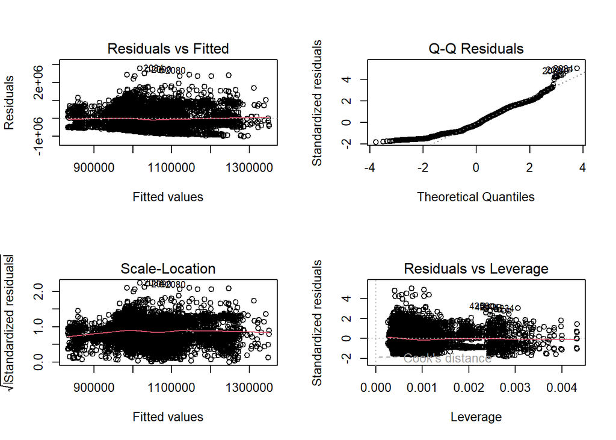

```r
# Residual analysis

# Residuals vs. Fitted Values Plot
par(mfrow=c(2,2))
plot(model)
```

Scale-Location Plot : Even spread so differences are consistent.